# lab4

## Task 4

Quadratic Model:

```r
quad.lm <- lm(Height~poly(BHDiameter, 2), data=spruce)
```

Quadratic Plot:

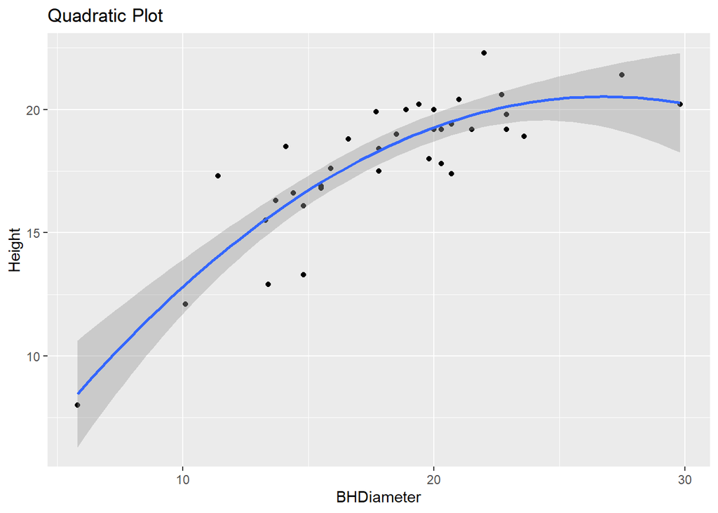

```r
ggplot(spruce,aes(x=BHDiameter, y=Height)) + geom_point() + stat_smooth(method = "lm", formula = y ~ x + I(x^2), size = 1) + ggtitle("Quadratic Plot")
```

Quad residuals and fitted.

```r
quad.res <- residuals(quad.lm)
quad.fit <- fitted(quad.lm)
```

Residuals plot:

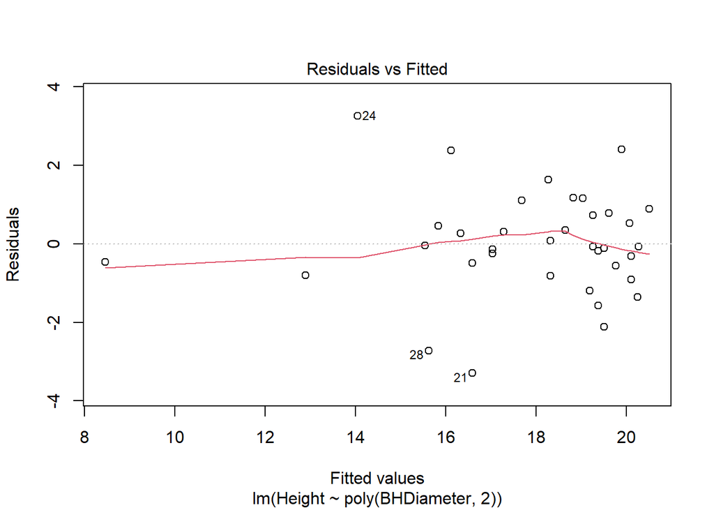

```r
plot(quad.lm, which =1)
```

Normcheck with Shapiro-Wilk:

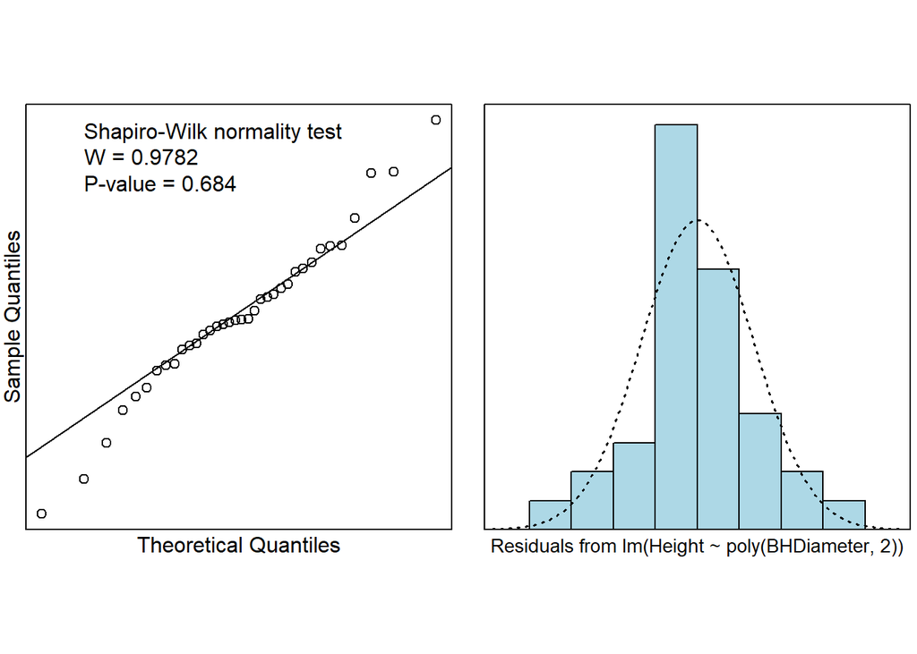

```r
normcheck(quad.lm, shapiro.wilk = TRUE)
```

The P-value is 0.684. We can conclude that this model fits the data pretty well, as the residuals have a normal distribution, have a mean of zero, and have fairly constant variance.

## Task 5

Summarize quad.lm

```r
summary(quad.lm)
```

```
##
## Call:
## lm(formula = Height ~ poly(BHDiameter, 2), data = spruce)
##
## Residuals:
##     Min      1Q  Median      3Q     Max
## -3.2966 -0.6245 -0.0707  0.7442  3.2541
##
## Coefficients:
##                      Estimate Std. Error t value Pr(>|t|)
## (Intercept)           17.9083     0.2303  77.762  < 2e-16 ***
## poly(BHDiameter, 2)1  13.5368     1.3818   9.797  2.7e-11 ***
## poly(BHDiameter, 2)2  -5.7180     1.3818  -4.138 0.000227 ***
## ---
## Signif. codes:  0 '***' 0.001 '**' 0.01 '*' 0.05 '.' 0.1 ' ' 1
##
## Residual standard error: 1.382 on 33 degrees of freedom
## Multiple R-squared:  0.7741, Adjusted R-squared:  0.7604
## F-statistic: 56.55 on 2 and 33 DF,  p-value: 2.182e-11
```

$$\widehat \beta_0 = 17.9083$$
$$\widehat \beta_1 = 13.5368$$
$$\widehat \beta_2 = -5.7180$$

```r
confint((quad.lm))
```

```
##                          2.5 %   97.5 %
## (Intercept)          17.439793 18.37687
## poly(BHDiameter, 2)1 10.725551 16.34803
## poly(BHDiameter, 2)2 -8.529278 -2.90680
```

|  | Lower Bound | Upper Bound |
| --- | --- | --- |
| $$\widehat \beta_0$$ | 17.4398 | 18.3769 |
| $$\widehat \beta_1$$ | 10.7255 | 16.3480 |
| $$\widehat \beta_2$$ | -8.5293 | -2.9068 |

```r
predict(quad.lm, data.frame(BHDiameter=c(15,18,20)))
```

```
##        1        2        3
## 16.72690 18.41740 19.26984
```

I predict that a diameter of 15 will give a height of 16.7269, a diameter of 18 will give a height of 18.4174, and a diameter of 20 will give a height of 19.2698.

Compared with the linear model:

```r
predict(spruce.lm, data.frame(BHDiameter=c(15,18,20)))
```

```
##        1        2        3
## 16.36895 17.81338 18.77632
```

|  | Quad | Linear |
| --- | --- | --- |
| 15 | 16.7269 | 16.3689 |
| 18 | 18.4174 | 17.8134 |
| 20 | 19.2698 | 18.7763 |

As we can see, the quadratic model gives a slightly higher value than the linear model.

```r
summary(spruce.lm)
```

```
##
## Call:
## lm(formula = Height ~ BHDiameter, data = spruce)
##
## Residuals:
##     Min      1Q  Median      3Q     Max
## -3.9394 -0.9763  0.2829  0.9950  2.6644
##
## Coefficients:
##             Estimate Std. Error t value Pr(>|t|)
## (Intercept)  9.14684    1.12131   8.157 1.63e-09 ***
## BHDiameter   0.48147    0.05967   8.069 2.09e-09 ***
## ---
## Signif. codes:  0 '***' 0.001 '**' 0.01 '*' 0.05 '.' 0.1 ' ' 1
##
## Residual standard error: 1.678 on 34 degrees of freedom
## Multiple R-squared:  0.6569, Adjusted R-squared:  0.6468
## F-statistic:  65.1 on 1 and 34 DF,  p-value: 2.089e-09
```

```r
summary(quad.lm)
```

```
##
## Call:
## lm(formula = Height ~ poly(BHDiameter, 2), data = spruce)
##
## Residuals:
##     Min      1Q  Median      3Q     Max
## -3.2966 -0.6245 -0.0707  0.7442  3.2541
##
## Coefficients:
##                      Estimate Std. Error t value Pr(>|t|)
## (Intercept)           17.9083     0.2303  77.762  < 2e-16 ***
## poly(BHDiameter, 2)1  13.5368     1.3818   9.797  2.7e-11 ***
## poly(BHDiameter, 2)2  -5.7180     1.3818  -4.138 0.000227 ***
## ---
## Signif. codes:  0 '***' 0.001 '**' 0.01 '*' 0.05 '.' 0.1 ' ' 1
##
## Residual standard error: 1.382 on 33 degrees of freedom
## Multiple R-squared:  0.7741, Adjusted R-squared:  0.7604
## F-statistic: 56.55 on 2 and 33 DF,  p-value: 2.182e-11
```

```r
anova(spruce.lm)
```

```
## Analysis of Variance Table
##
## Response: Height
##            Df  Sum Sq Mean Sq F value    Pr(>F)
## BHDiameter  1 183.245 183.245  65.101 2.089e-09 ***
## Residuals  34  95.703   2.815
## ---
## Signif. codes:  0 '***' 0.001 '**' 0.01 '*' 0.05 '.' 0.1 ' ' 1
```

```r
anova(quad.lm)
```

```
## Analysis of Variance Table
##
## Response: Height
##                     Df  Sum Sq Mean Sq F value    Pr(>F)
## poly(BHDiameter, 2)  2 215.941 107.970   56.55 2.182e-11 ***
## Residuals           33  63.007   1.909
## ---
## Signif. codes:  0 '***' 0.001 '**' 0.01 '*' 0.05 '.' 0.1 ' ' 1
```

The quadratic model has lower residual sum of squares and a lower mean sum of squares, meaning that it fits the model better.

$$RSS= 63.007, MSS = 215.941, TSS = 278.9475$$

$$\frac{MSS} {TSS} = R^2 = .7741$$

## Task 6

Cook’s plot: (cooks20x is not available for my version of R (4.0.2), so I’m making do with another test)

```r
library(car)
```

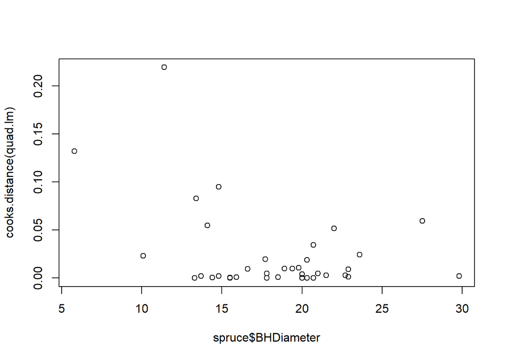

```r
plot(spruce$BHDiameter, cooks.distance(quad.lm))
```

Cooks distance is commonly used to check for the validity of a data point. Data points with high cooks distances are likely to be outliers and unduly distort the model.

Applying the cooks methods to the quadratic model suggests that Height values for lower BHDiameters have a greater potential to be outliers, so they should be investigated in more detail.

Removing datum with highest cooks distance:

```r
spruceRemoved <- spruce[-24, ]
quad2.lm <- lm(Height~poly(BHDiameter, 2), data=spruceRemoved)
summary(quad2.lm)
```

```
##
## Call:
## lm(formula = Height ~ poly(BHDiameter, 2), data = spruceRemoved)
##
## Residuals:
##      Min       1Q   Median       3Q      Max
## -3.11233 -0.48227  0.01253  0.71727  2.59146
##
## Coefficients:
##                      Estimate Std. Error t value Pr(>|t|)
## (Intercept)            17.926      0.214  83.773  < 2e-16 ***
## poly(BHDiameter, 2)1   13.807      1.266  10.907 2.60e-12 ***
## poly(BHDiameter, 2)2   -6.054      1.266  -4.782 3.74e-05 ***
## ---
## Signif. codes:  0 '***' 0.001 '**' 0.01 '*' 0.05 '.' 0.1 ' ' 1
##
## Residual standard error: 1.266 on 32 degrees of freedom
## Multiple R-squared:  0.8159, Adjusted R-squared:  0.8044
## F-statistic: 70.91 on 2 and 32 DF,  p-value: 1.74e-12
```

```r
summary(quad.lm)
```

```
##
## Call:
## lm(formula = Height ~ poly(BHDiameter, 2), data = spruce)
##
## Residuals:
##     Min      1Q  Median      3Q     Max
## -3.2966 -0.6245 -0.0707  0.7442  3.2541
##
## Coefficients:
##                      Estimate Std. Error t value Pr(>|t|)
## (Intercept)           17.9083     0.2303  77.762  < 2e-16 ***
## poly(BHDiameter, 2)1  13.5368     1.3818   9.797  2.7e-11 ***
## poly(BHDiameter, 2)2  -5.7180     1.3818  -4.138 0.000227 ***
## ---
## Signif. codes:  0 '***' 0.001 '**' 0.01 '*' 0.05 '.' 0.1 ' ' 1
##
## Residual standard error: 1.382 on 33 degrees of freedom
## Multiple R-squared:  0.7741, Adjusted R-squared:  0.7604
## F-statistic: 56.55 on 2 and 33 DF,  p-value: 2.182e-11
```

Removing that data point increased the multiple r-squared to 0.8159, making the new model slightly more accurate.

## Task 7

piecewise regression:

```r
sp2.df=within(spruce, X<-(BHDiameter-18)*(BHDiameter>18))
sp2.df
```

```
##    BHDiameter Height    X
## 1        18.9   20.0  0.9
## 2        16.6   18.8  0.0
## 3        15.5   16.8  0.0
## 4        15.5   16.9  0.0
## 5        19.4   20.2  1.4
## 6        13.7   16.3  0.0
## 7        20.0   20.0  2.0
## 8        27.5   21.4  9.5
## 9        29.8   20.2 11.8
## 10       20.3   19.2  2.3
## 11       19.8   18.0  1.8
## 12       22.9   19.8  4.9
## 13       20.3   17.8  2.3
## 14       14.1   18.5  0.0
```

[output cut: 22 more lines]

```r
lmp=lm(Height~BHDiameter + X,data=sp2.df)
tmp=summary(lmp)
names(tmp)
```

```
##  [1] "call"          "terms"         "residuals"     "coefficients"
##  [5] "aliased"       "sigma"         "df"            "r.squared"
##  [9] "adj.r.squared" "fstatistic"    "cov.unscaled"
```

```r
myf = function(x,coef){
  coef[1]+coef[2]*(x) + coef[3]*(x-18)*(x-18>0)
}
plot(spruce,main="Piecewise regression")
myf(0, coef=tmp$coefficients[,"Estimate"])
```

```
## (Intercept)
##    4.499237
```

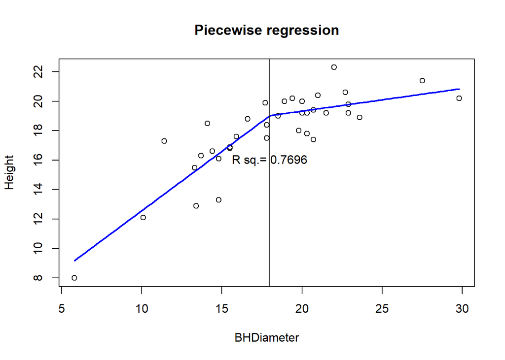

```r
curve(myf(x,coef=tmp$coefficients[,"Estimate"] ),add=TRUE, lwd=2,col="Blue")
abline(v=18)
text(18,16,paste("R sq.=",round(tmp$r.squared,4) ))
```

## Task 8

### Function for lab 1.

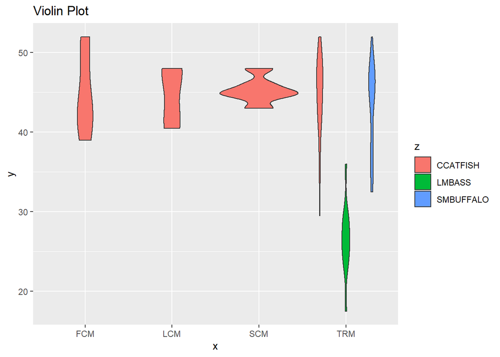

```r
library(MATH4753PREU0001)
ddt <- read.csv("DDT.csv")
violPlot(ddt, ddt$RIVER, ddt$LENGTH, ddt$SPECIES)
```

This function creates a simple violin plot based on the given data. It uses ggplot2 to create the plot, and it offers almost no way for the user to customize the graph. But if they don’t know how to use ggplot and just wanted a violin plot, this function would create a violin plot for them.

### Function for lab 2

```r
spruceVector <- as.vector(spruce[,1])
library(MATH4753PREU0001)
chebyshev(2, spruceVector)
```

```
## [1] 0.9444444
```

This function determines the percentage of data entries that fall within a specified number of standard deviations of the mean. This function is useful when demonstrating Chebyshev’s rule.

### Function for lab 3

```r
tmr(spruce$Height, spruce$BHDiameter, spruce)
```

```
## [1] 278.94750 183.24469  95.70281
```

This function determines the TSS, MSS, and RSS for a certain data set. This is helpful because the summary function does not display these raw values and instead returns calculated values like multiple r-squared.

### Function for lab 4

```r
fitCompare(spruce.lm, quad.lm)
```

```
## [1] "model 2"
```

This function compares the multiple r-squared of 2 different models and tells the user which model has a better fit. This is useful when the user has multiple different models floating around and needs to quickly determine which model explains the most variance without having to hunt through the summary function of two models and comparing them.